# Reproducible Research Project 2 - US NOAA Storm Database: health and economic consequences of severe weather

Brandon Robinson

2024-03-10

## Synopsis

The second project of the Coursera course Reproducible Data, requires the student to analyze the health and economic consequences of severe weather between the years 1950 - 2011. The data to be analyzed will be provided by US NOAA database which tracks weather events across the US. The questions to answer are as follows:

1. Across the United States, which types of events (as indicated by the *EVTYPE* variable) are most harmful with respect to population health?
2. Across the United States, which types of events have the greatest economic consequences?

## Loading and Pre-Processing the Data

First the following packages will be loaded before running further code

```r
library(R.utils)
library(data.table)
library(dplyr)
```

```r
library(ggplot2)
library(tidyr)
```

Next, the storm data file is downloaded and stored

```r
if (!file.exists("stormdata.csv.bz2")) {
        fileURL <- "https://d396qusza40orc.cloudfront.net/repdata%2Fdata%2FStormData.csv.bz2"
        download.file(fileURL, "stormdata.csv.bz2")
        bunzip2("stormdata.csv.bz2", "stormdata.csv", remove=FALSE)
}
storm <- data.table::fread("stormdata.csv", fill=TRUE, header=TRUE)
head(storm)
```

```
##    STATE__           BGN_DATE BGN_TIME TIME_ZONE COUNTY COUNTYNAME STATE
## 1:    1.00  4/18/1950 0:00:00     0130       CST     97     MOBILE    AL
## 2:    1.00  4/18/1950 0:00:00     0145       CST      3    BALDWIN    AL
## 3:    1.00  2/20/1951 0:00:00     1600       CST     57    FAYETTE    AL
## 4:    1.00   6/8/1951 0:00:00     0900       CST     89    MADISON    AL
## 5:    1.00 11/15/1951 0:00:00     1500       CST     43    CULLMAN    AL
## 6:    1.00 11/15/1951 0:00:00     2000       CST     77 LAUDERDALE    AL
##     EVTYPE BGN_RANGE BGN_AZI BGN_LOCATI END_DATE END_TIME COUNTY_END COUNTYENDN
## 1: TORNADO         0                                               0         NA
## 2: TORNADO         0                                               0         NA
## 3: TORNADO         0                                               0         NA
## 4: TORNADO         0                                               0         NA
## 5: TORNADO         0                                               0         NA
## 6: TORNADO         0                                               0         NA
##    END_RANGE END_AZI END_LOCATI LENGTH WIDTH F MAG FATALITIES INJURIES PROPDMG
```

[output cut: 20 more lines]

Review the column names and extract only the required names for analysis

```r
names(storm)
```

```
##  [1] "STATE__"    "BGN_DATE"   "BGN_TIME"   "TIME_ZONE"  "COUNTY"
##  [6] "COUNTYNAME" "STATE"      "EVTYPE"     "BGN_RANGE"  "BGN_AZI"
## [11] "BGN_LOCATI" "END_DATE"   "END_TIME"   "COUNTY_END" "COUNTYENDN"
## [16] "END_RANGE"  "END_AZI"    "END_LOCATI" "LENGTH"     "WIDTH"
## [21] "F"          "MAG"        "FATALITIES" "INJURIES"   "PROPDMG"
## [26] "PROPDMGEXP" "CROPDMG"    "CROPDMGEXP" "WFO"        "STATEOFFIC"
## [31] "ZONENAMES"  "LATITUDE"   "LONGITUDE"  "LATITUDE_E" "LONGITUDE_"
## [36] "REMARKS"    "REFNUM"
```

```r
stormdata <- storm %>% select(c("EVTYPE","FATALITIES","INJURIES","PROPDMG","PROPDMGEXP","CROPDMG","CROPDMGEXP"))
str(stormdata)
```

```
## Classes 'data.table' and 'data.frame':   902297 obs. of  7 variables:
##  $ EVTYPE    : chr  "TORNADO" "TORNADO" "TORNADO" "TORNADO" ...
##  $ FATALITIES: num  0 0 0 0 0 0 0 0 1 0 ...
##  $ INJURIES  : num  15 0 2 2 2 6 1 0 14 0 ...
##  $ PROPDMG   : num  25 2.5 25 2.5 2.5 2.5 2.5 2.5 25 25 ...
##  $ PROPDMGEXP: chr  "K" "K" "K" "K" ...
##  $ CROPDMG   : num  0 0 0 0 0 0 0 0 0 0 ...
##  $ CROPDMGEXP: chr  "" "" "" "" ...
##  - attr(*, ".internal.selfref")=<externalptr>
```

The remaining variables for analysis are:

1. EVTYPE - storm event type
2. FATALITIES - fatalities per event
3. INJURIES - injuries per event
4. PROPDMG -property damage cost
5. PROPDMGEXP - property damage exponent
6. CROPDMG - cropdamage cost
7. CROPDMGEXP - crop damage exponent

## Processing Data

The next step is to process the data based on the questions to be answered. The first question asks which storm events are most harmful with respect to population health.

### Question 1

The data will be processed by grouping event type with the total injuries and deaths. Then, the data will be grouped in descending order to clearly delineate the most harmful storm type. The goal is to get the data on the same plot for easier comparison

```r
totalInjuries <- aggregate(INJURIES ~ EVTYPE, data = stormdata, FUN = sum)
topInjuries <- totalInjuries[order(-totalInjuries$INJURIES), ]
totalFatalities <- aggregate(FATALITIES ~ EVTYPE, data = stormdata, FUN = sum)
topFatalities <- totalFatalities[order(-totalFatalities$FATALITIES), ]

#### combine the injury and fatality data to one table and order the top 10

topHealth <- merge(topInjuries, topFatalities, all.x = TRUE)
topHealth[is.na(topHealth)] <- 0
topHealth2 <- topHealth[order(-topHealth$INJURIES),][1:10,]
topHealth2 <- gather(topHealth2,key=type, value=value, INJURIES,FATALITIES)
```

### Question 2

The second question asks which storm types have the greatest economic consequences. The methodology to determine the economic impact will be similar to the injuries and fatalities, but with a few extra steps to aggregate the costs. The data will be combined in order to be viewable on the same plot.

The first step is to create a function to set the property damage exponents to real numbers. This will allow us to collect the damage costs to property and crops

```r
cost <- function(x) {
        if (x == "H")
                100
        else if (x == "K")
                1000
        else if (x == "M")
                1e+06
        else if (x == "B")
                1e+09
        else if (x == "")
                1
        else if (x == "m")
                1e+06
        else if (x == "0")
                1
        else if (x == "5")
                1e+05
        else if (x == "6")
                1e+06
        else if (x == "4")
                10000
        else if (x == "2")
                100
        else if (x == "3")
                1000
        else if (x == "h")
                100
        else if (x == "7")
                1e+07
        else if (x == "1")
                10
        else if (x == "8")
                1e+08
        else
                0
}
```

Next the data will be processed by grouping event type with property and crop damage costs. Then, the data will be grouped in descending order to clearly delineate the greatest economic impact.

```r
econdata <- storm %>% select(c("EVTYPE","PROPDMG","PROPDMGEXP","CROPDMG","CROPDMGEXP"))
econdata$Property <-  econdata$PROPDMG*sapply(econdata$PROPDMGEXP, FUN = cost)
econdata$Crops <- econdata$CROPDMG*sapply(econdata$CROPDMGEXP, FUN = cost)
dmgValue <- aggregate(Property~EVTYPE,data = econdata, FUN = sum, na.rm = TRUE)
dmgValue <- dmgValue[with(dmgValue,order(-Property)),]
cropValue <- aggregate(Crops~EVTYPE,data = econdata, FUN = sum, na.rm = TRUE)
cropValue <- cropValue[with(cropValue,order(-Crops)),]

#### combine economic losses into one table and order the top 10

topDmg <- merge(dmgValue, cropValue, all.x = TRUE)
topDmg[is.na(topDmg)] <- 0
topDmg2 <- topDmg[order(-topDmg$Property),][1:10,]
topDmg2 <- gather(topDmg2,key=type, value=value, Property,Crops)
```

## Results and Conclusions

The first question asked for the events which caused the most fatalities and injuries. The below plot represents the top 10 storm events which were most harmful to population health

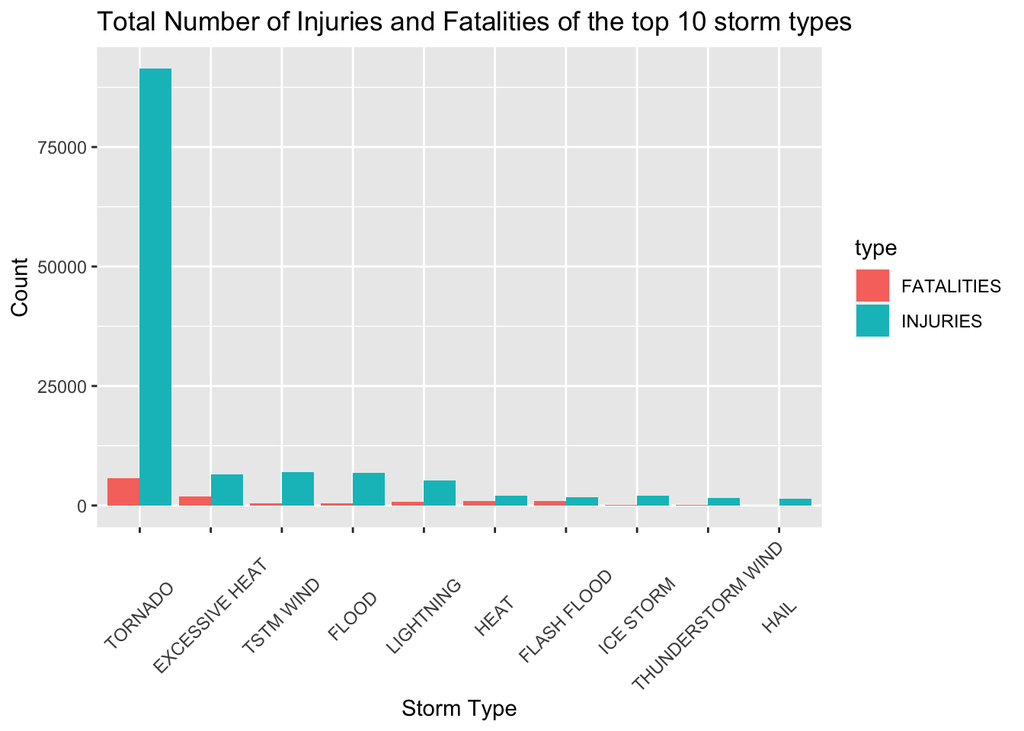

```r
damagePlot <- ggplot(data=topHealth2, aes(reorder(EVTYPE, -value), value, fill=type)) +
        geom_bar(position = "dodge", stat="identity") +
        labs(x="Storm Type", y="Count") +
        theme(axis.text.x = element_text(angle = 45, vjust=0.5)) +
        ggtitle("Total Number of Injuries and Fatalities of the top 10 storm types")
print(damagePlot)
```

Based on the plot, Tornados had the greatest impact on population health.

The second question asked for the storm events which had the greatest economic consequences. The below plot represents the top 10 storm events with the greatest economic consequences.

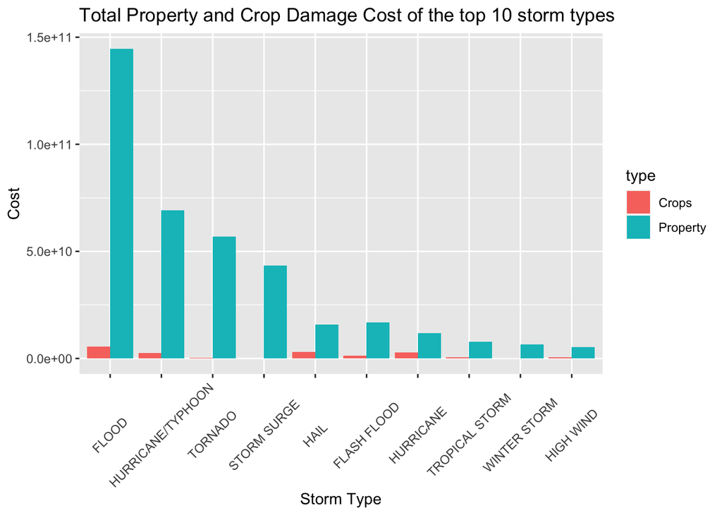

```r
costPlot <- ggplot(data=topDmg2, aes(reorder(EVTYPE, -value), value, fill=type)) +
        geom_bar(position = "dodge", stat="identity") +
        labs(x="Storm Type", y="Cost") +
        theme(axis.text.x = element_text(angle = 45, vjust=0.5)) +
        ggtitle("Total Property and Crop Damage Cost of the top 10 storm types")
print(costPlot)
```

Based on the plot, Floods had the greatest economic loss impact in the US